# Understanding Large-N Analyses

## Welcome to the large-N world!

## How large is a Large-N N?

Let's revisit the toss of coin:

- Tossing once? Head or Tail?

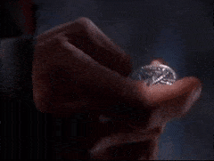

Tossing 1 million times? How many heads?

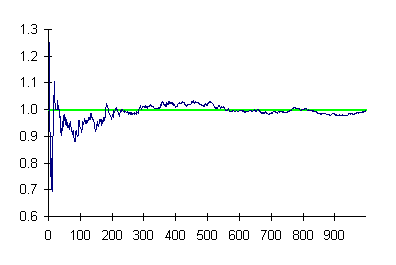

## Law of Large numbers

As the number of experiments (sample) increases, the ratio of outcomes will converge to the theoretical (population) average.

- Rule of thumb: \(> 100\)

## How to analyze large-N data?

- Univariate analysis
- Bivariate analysis
- Multivariate analysis

## Univariate analysis

How can we describe a variable?

- Creating the expectation of a variable
  - Given a list: \((1, 1, 1, 2, 3, 3, 4)\)
  - Mean: \(\frac{1 + 1 + 1 + 2 + 3 + 3 + 4}{7} = \frac{15}{7} \approx 2.143.\)
  - Median: 1, 1, 1, **2**, 3, 3, 4
  - Mode: three 1s, one 2, two 3s, and one 4.

## Example in large-N data

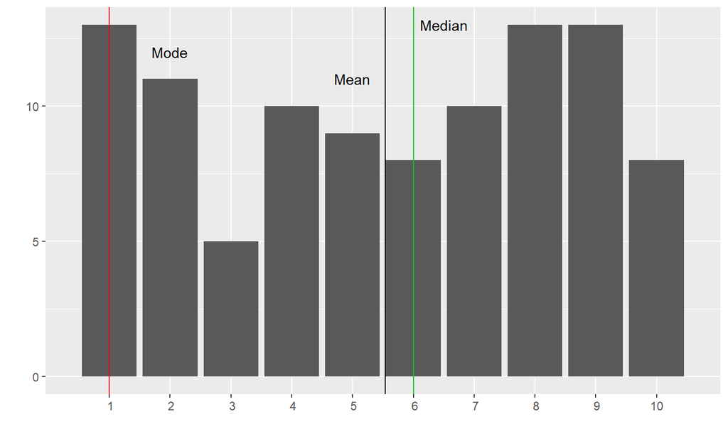

## Which one should we choose?

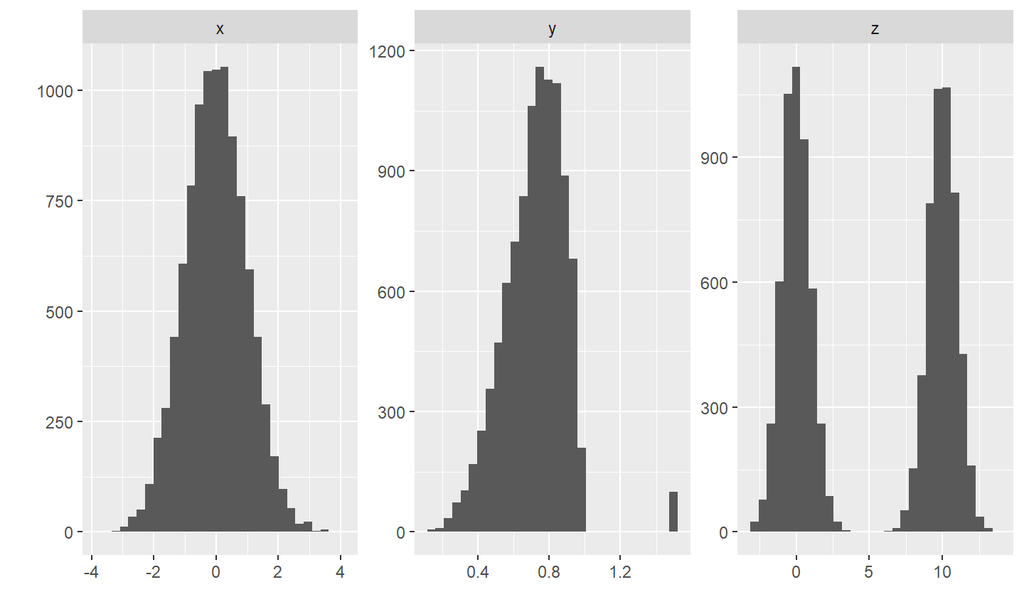

## Moments of a variable

Mean: \(\mu_x = \frac{\sum X_i}{N};\) Variance: \(\sigma^2_x = E[(X - \mu_x)^2].\)

[figure not shown]

Skewness: \(\gamma_x = E[(\frac{X - \mu_x}{\sigma})^3].\)

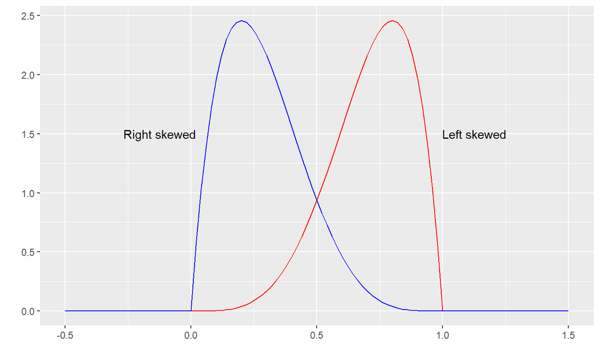

Kurtosis: \(\kappa_x = E[(\frac{X - \mu_X}{\sigma})^4].\)

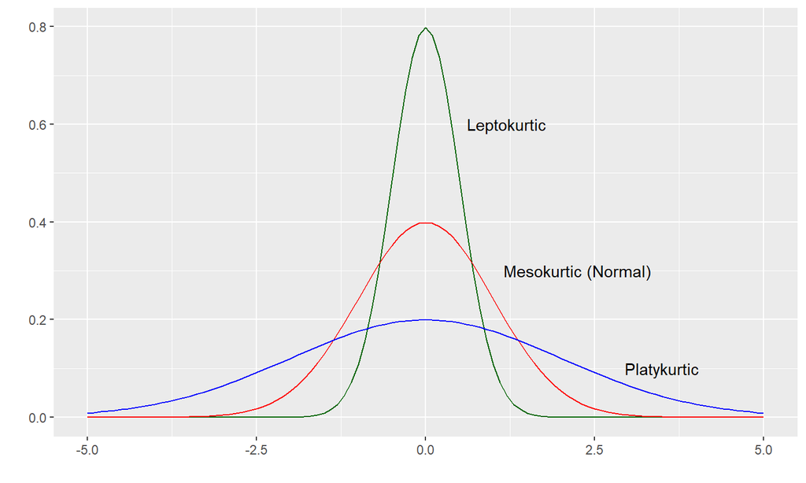

## Descriptive Statistics

| am | Min. :0.0000 | 1st Qu.:0.0000 | Median :0.0000 | Mean :0.4062 | 3rd Qu.:1.0000 | Max. :1.0000 |
| --- | --- | --- | --- | --- | --- | --- |
| carb | Min. :1.000 | 1st Qu.:2.000 | Median :2.000 | Mean :2.812 | 3rd Qu.:4.000 | Max. :8.000 |
| cyl | Min. :4.000 | 1st Qu.:4.000 | Median :6.000 | Mean :6.188 | 3rd Qu.:8.000 | Max. :8.000 |
| gear | Min. :3.000 | 1st Qu.:3.000 | Median :4.000 | Mean :3.688 | 3rd Qu.:4.000 | Max. :5.000 |
| vs | Min. :0.0000 | 1st Qu.:0.0000 | Median :0.0000 | Mean :0.4375 | 3rd Qu.:1.0000 | Max. :1.0000 |

## Even better…

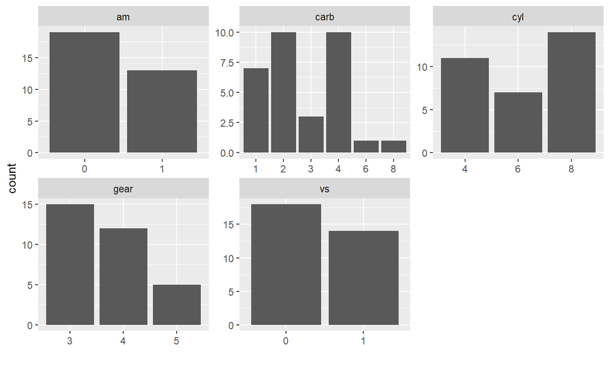

## How to describe a relationship?

Contingency table:

```
##    Cell Contents
## |-------------------------|
## |                       N |
## |         N / Table Total |
## |-------------------------|
##
## ============================================
##                mtcars$cyl
## mtcars$gear        4       6       8   Total
## --------------------------------------------
## 3                  1       2      12      15
##                0.031   0.062   0.375
## --------------------------------------------
## 4                  8       4       0      12
##                0.250   0.125   0.000
## --------------------------------------------
## 5                  2       1       2       5
##                0.062   0.031   0.062
## --------------------------------------------
## Total             11       7      14      32
## ============================================
```

## Scatter plot

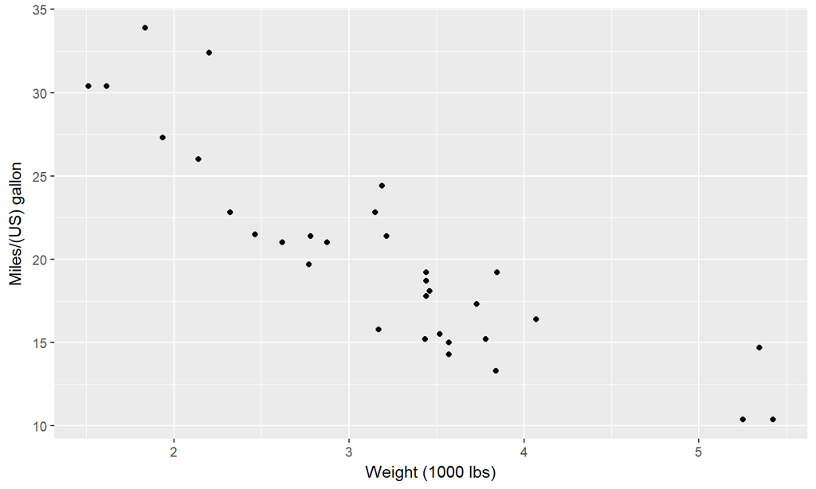

## Do a multivariate analysis

## Example: Tang, Hu, and Jin (2016)

Puzzle: Same education level, but difference in labor mobility between Han and Uyghur

[figure not shown]

[figure not shown]

## Theory

Affirmative inaction language policy reduces Uyghurs' labor mobility.

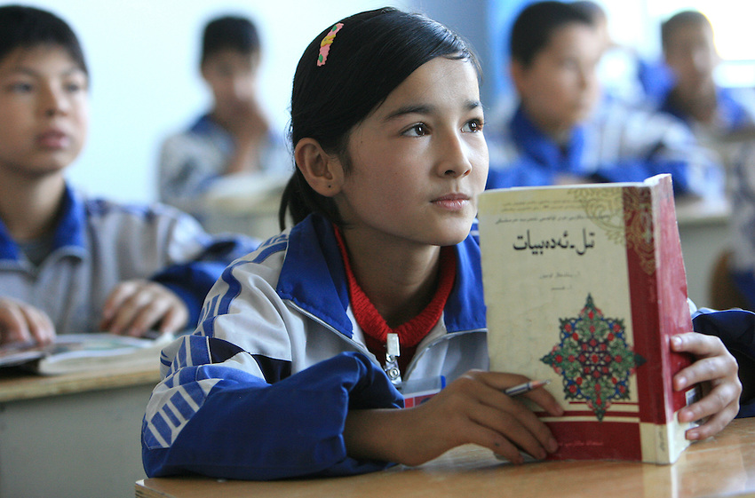

## Hypothesis:

- \(H_1\): Education is fairly equal between the Han and the Uyghur groups.
- \(H_2\): The linguistically distinctive Uyghurs are far less proficient in Mandarin than the Han majority.
- \(H_3\): Hans enjoy a higher degree of socioeconomic status than the Uyghurs.
- \(H_4\): Language proficiency plays a favorable role in improving the socioeconomic conditions for the Uyghurs.

## Examination

\(H_{1,2}\): Education is fairly equal between the Han and the Uyghur groups.

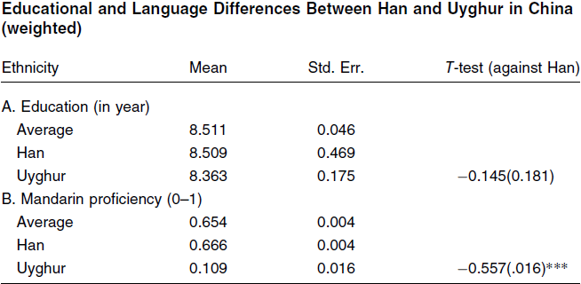

\(H_2\): The linguistically distinctive Uyghurs are far less proficient in Mandarin than the Han majority.

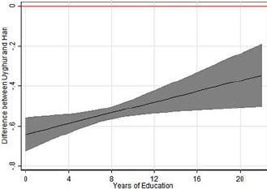

\(H_3\): Hans enjoy a higher labor mobility than the Uyghurs.

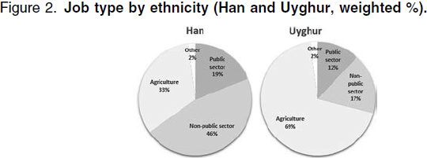

\(H_4\): Language proficiency plays a favorable role in improving the socioeconomic conditions for the Uyghurs.

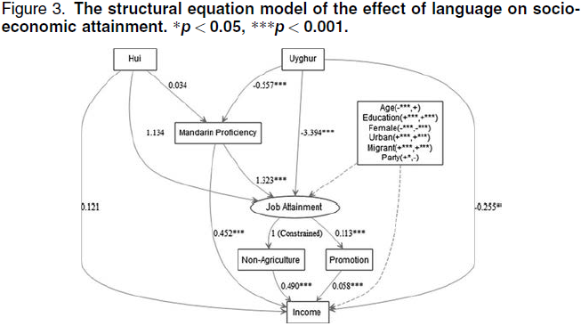

## Wrap up

### Understand Large-N Analysis

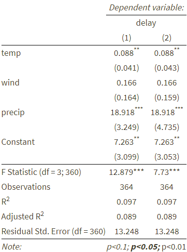

### Do large-N analyses

- Elaborate the puzzle
- Set up the theory
- Imply hypotheses
- Design empirical examination
- Data analysis
- Result discussion